# Lab 6a - Network Models

Douglas Luke

July 16, 2021

## Introduction

This lab corresponds to Chapter 10 - Models of Network Structure and Prominence.

We will use `igraph` in this chapter, which has many more functions available to create random networks based on mathematical or structural models. Also, some of the code relies on functions contained in the `tidyverse` suite of packages; namely, `purrr`.

```r
library(igraph)
library(UserNetR)
library(purrr)
library(lattice)
```

## Erdos-Renyi Random Graphs

These are the simplest models, because they are purely random models. That is, ties between nodes are determined randomly.

Note that the model functions in igraph have new names, to be more consistent across the set of functions. The old function names that you find in the book are *deprecated*. That means the old function names still work, but they may not in future versions of the package.

In `igraph`, there are two functions that can do Erdos-Renyi networks. The only difference is whether you specify the probability of a tie between two nodes, or how many ties.

```r
g <- sample_gnm(n=12,10)
g
```

```
## IGRAPH a980190 U--- 12 10 -- Erdos renyi (gnm) graph
## + attr: name (g/c), type (g/c), loops (g/l), m (g/n)
## + edges from a980190:
##  [1]  2-- 4  1-- 7  4-- 7  5-- 7  2-- 8  5-- 8  8--10 10--11  1--12  4--12
```

```r
graph.density(g)
```

```
## [1] 0.1515152
```

```r
g <- sample_gnp(n=12,.15)
g
```

```
## IGRAPH a981037 U--- 12 4 -- Erdos renyi (gnp) graph
## + attr: name (g/c), type (g/c), loops (g/l), p (g/n)
## + edges from a981037:
## [1] 1-- 2 1-- 4 1--10 2--10
```

```r
graph.density(g)
```

```
## [1] 0.06060606
```

Run the following a few times to see the random nature of these graphs.

[figure not shown]

```r
op <- par(mar=c(0,1,3,1),mfrow=c(1,2))
plot(sample_gnp(n=25,.15),
                      vertex.color=2,
                      main="First random graph")
plot(sample_gnp(n=25,.15),
                      vertex.color=4,
                      main="Second random graph")
```

```r
par(op)
```

The shape of the degree distribution is an important characteristic of networks, and helps to distinguish among different network models. For large random graphs, you should see a Poisson degree distributions.

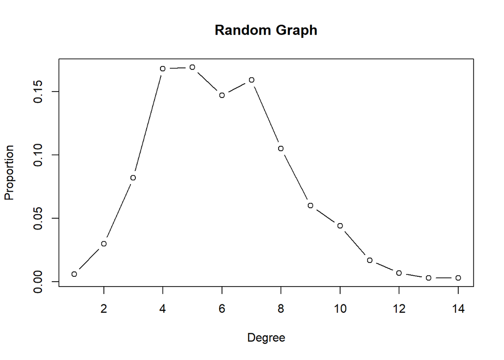

```r
g <- sample_gnp(n=1000,.005)
plot(degree.distribution(g),
     type="b",xlab="Degree",ylab="Proportion",
     main="Random Graph")
```

E: What happens as the size of the network gets larger? What happens if the probability of a tie increases or decreases?

The following examples demonstrate some of the emergent characteristics of random networks. See the chapter for more explanation. However, this code also demonstrates how statistical analysis can be conducted with network models, to better understand the full implications of these models.

To understand this simple simulation, you should understand the `apply` family of iterating functions in R (apply,lapply,sapply).

First, create a function that returns the proportion of nodes in the largest connected component of a random graph relative to the total number of nodes. (If the entire network is in one component, then the proportion will be 1.)

```r
cmpprp <- function(deg){
  cmp_prp <- max(clusters(sample_gnp(n=1000,
                      p=deg/999))$csize)/1000
  cmp_prp
}
```

```r
crnd <- runif(500,1,8)
cmp_vec <- map_dbl(crnd,cmpprp)
```

Finally, we can plot the component proportion against the average degree. This will reveal the relationship between the average degree in a random graph, and how connected the graph might be.

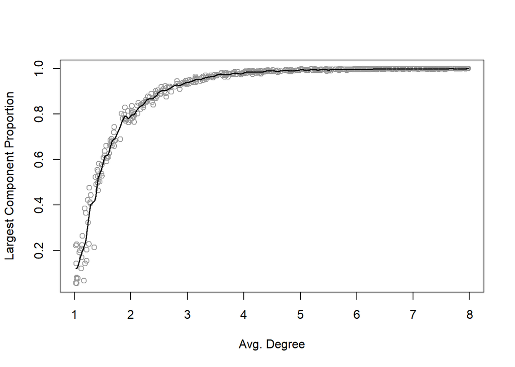

```r
smoothingSpline <- smooth.spline(crnd,cmp_vec,
                                 spar=0.25)
plot(crnd,cmp_vec,col='grey60',
     xlab="Avg. Degree",
     ylab="Largest Component Proportion")
lines(smoothingSpline,lwd=1.5)
```

Second, random networks can still exhibit ‘small world’ properties.

The plot in the following code uses the `lattice` graphics package. Make sure to download and install it before running.

```r
n_vect <- rep(c(50,100,500,1000,5000),each=50)
g_diam <- sapply(n_vect,function(x)
  diameter(sample_gnp(n=x,p=6/(x-1))))
```

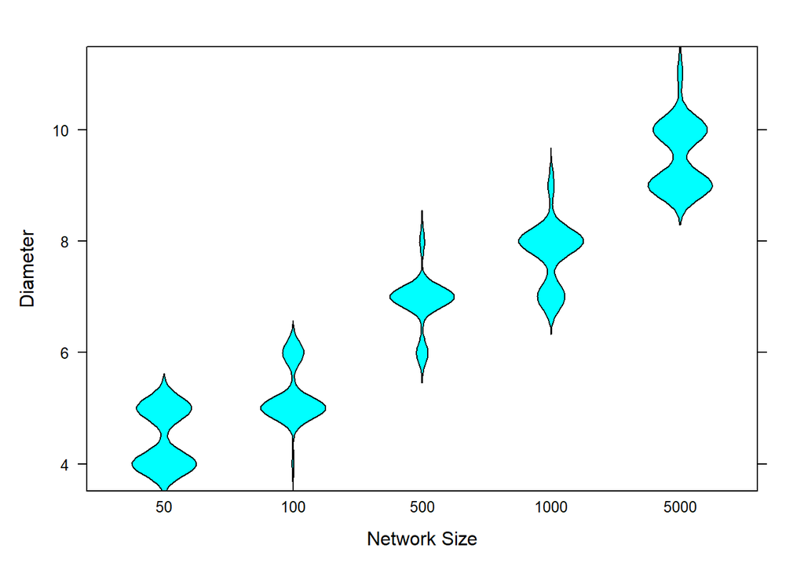

```r
bwplot(g_diam ~ factor(n_vect),
       panel=panel.violin,
       xlab="Network Size",
       ylab="Diameter")
```

Q: Reflect on how the above characteristics of random networks are connected to the idea of ‘6-Degrees of Separation’ and Milgram’s small-world study.

## Small-World Model

The first code chunk shows how small-world networks are constructed, and how they look as the *rewiring* probability increases. If the rewiring probability is high enough, the network will just become a random graph.

It also shows how sometimes the easy things are hard in R. The `expression()` and `paste()` parts of the plot command are just so we can include italics in the figure captions.

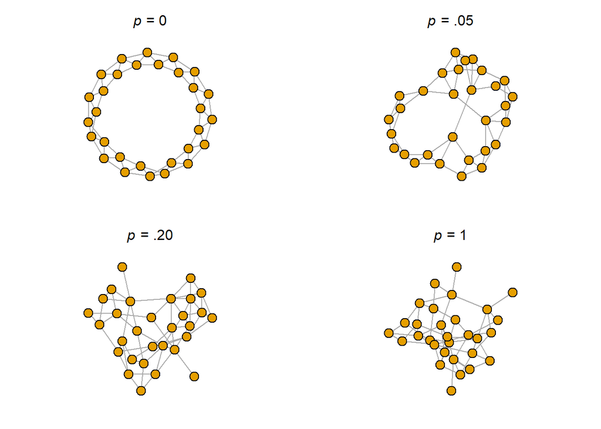

```r
g1 <- sample_smallworld(dim=1, size=30, nei=2, p=0)
g2 <- sample_smallworld(dim=1, size=30, nei=2, p=.05)
g3 <- sample_smallworld(dim=1, size=30, nei=2, p=.20)
g4 <- sample_smallworld(dim=1, size=30, nei=2, p=1)
op <- par(mar=c(2,1,3,1),mfrow=c(2,2))
plot(g1,vertex.label=NA,layout=layout_with_kk,
     main=expression(paste(italic(p)," = 0")))
plot(g2,vertex.label=NA,
     main=expression(paste(italic(p)," = .05")))
plot(g3,vertex.label=NA,
     main=expression(paste(italic(p)," = .20")))
plot(g4,vertex.label=NA,
     main=expression(paste(italic(p)," = 1")))
```

```r
par(op)
```

The pure lattice structure that we start with implies that the diameter of a network will be relatively high, because each node is only connected to close neighbors.

```r
g100 <- sample_smallworld(dim=1,size=100,nei=2,p=0)
g100
```

```
## IGRAPH c32723a U--- 100 200 -- Watts-Strogatz random graph
## + attr: name (g/c), dim (g/n), size (g/n), nei (g/n), p (g/n), loops
## | (g/l), multiple (g/l)
## + edges from c32723a:
##  [1]  1-- 2  2-- 3  3-- 4  4-- 5  5-- 6  6-- 7  7-- 8  8-- 9  9--10 10--11
## [11] 11--12 12--13 13--14 14--15 15--16 16--17 17--18 18--19 19--20 20--21
## [21] 21--22 22--23 23--24 24--25 25--26 26--27 27--28 28--29 29--30 30--31
## [31] 31--32 32--33 33--34 34--35 35--36 36--37 37--38 38--39 39--40 40--41
## [41] 41--42 42--43 43--44 44--45 45--46 46--47 47--48 48--49 49--50 50--51
## [51] 51--52 52--53 53--54 54--55 55--56 56--57 57--58 58--59 59--60 60--61
## [61] 61--62 62--63 63--64 64--65 65--66 66--67 67--68 68--69 69--70 70--71
## + ... omitted several edges
```

```r
diameter(g100)
```

```
## [1] 25
```

The following, rather arduous, code shows how the diameter of a network gets rapidly smaller with modest increases in the rewiring probability.

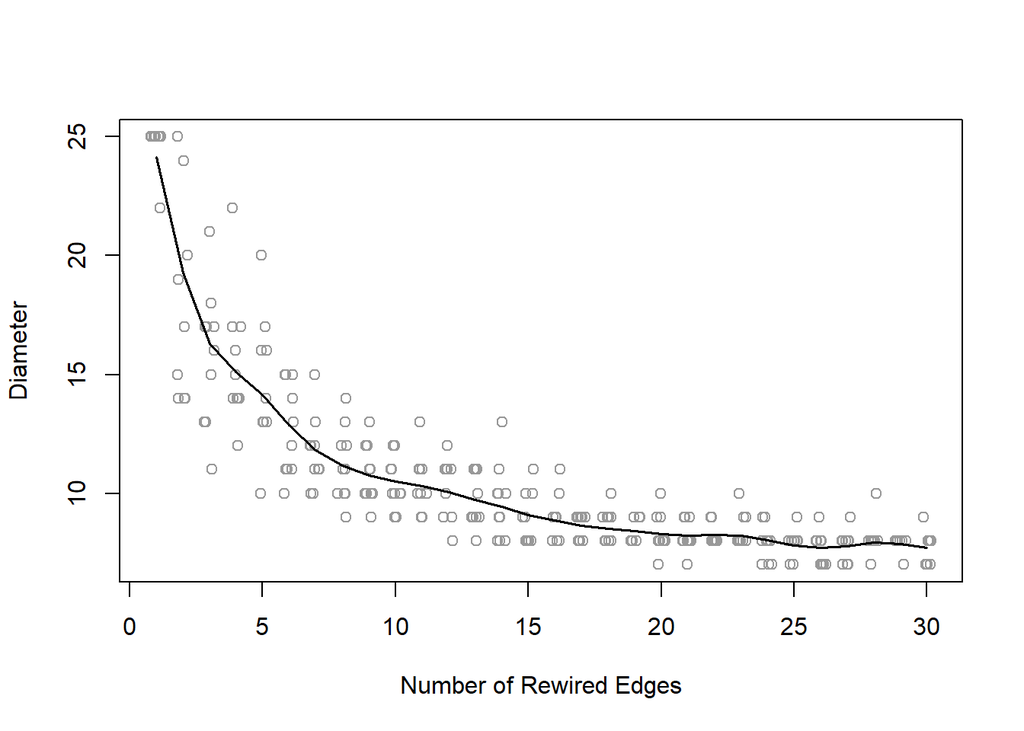

```r
p_vect <- rep(1:30,each=10)
g_diam <- map_dbl(p_vect,function(x)
  diameter(sample_smallworld(dim=1, size=100,
                               nei=2, p=x/200)))
smoothingSpline = smooth.spline(p_vect, g_diam,
                                spar=0.35)
plot(jitter(p_vect,1),g_diam,col='grey60',
     xlab="Number of Rewired Edges",
     ylab="Diameter")
lines(smoothingSpline,lwd=1.5)
```

## Scale-free (Power Law) Network Model

First, we define a rescale function which is used in the following plots.

```r
rescale <- function(node_char,low,high) {
  min_d <- min(node_char)
  max_d <- max(node_char)
  rscl <- ((high - low)*(node_char - min_d))/(max_d - min_d) + low
  rscl
}
```

The new model function name is `sample_pa()` (for preferential attachment).

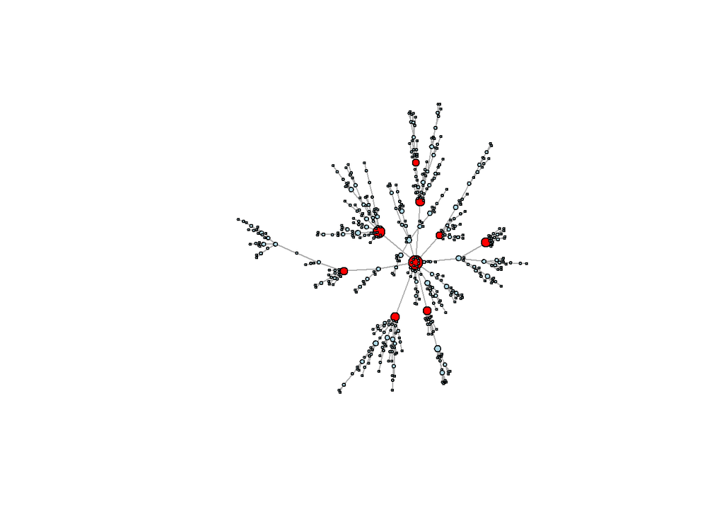

```r
g <- sample_pa(500,directed=FALSE)
V(g)$color <- 'lightblue'
V(g)[degree(g) > 9]$color <- 'red'
node_size <- rescale(node_char=degree(g),
                     low=2,high=10)
plot(g, vertex.label= NA, vertex.size = node_size)
```

The heavy-tailed degree distribution of a scale-free network is easy to see.

```r
degree_distribution(g)
```

```
##  [1] 0.000 0.604 0.210 0.066 0.046 0.024 0.020 0.008 0.002 0.002 0.004 0.002
## [13] 0.002 0.002 0.000 0.004 0.000 0.000 0.000 0.000 0.002 0.000 0.000 0.000
## [25] 0.002
```

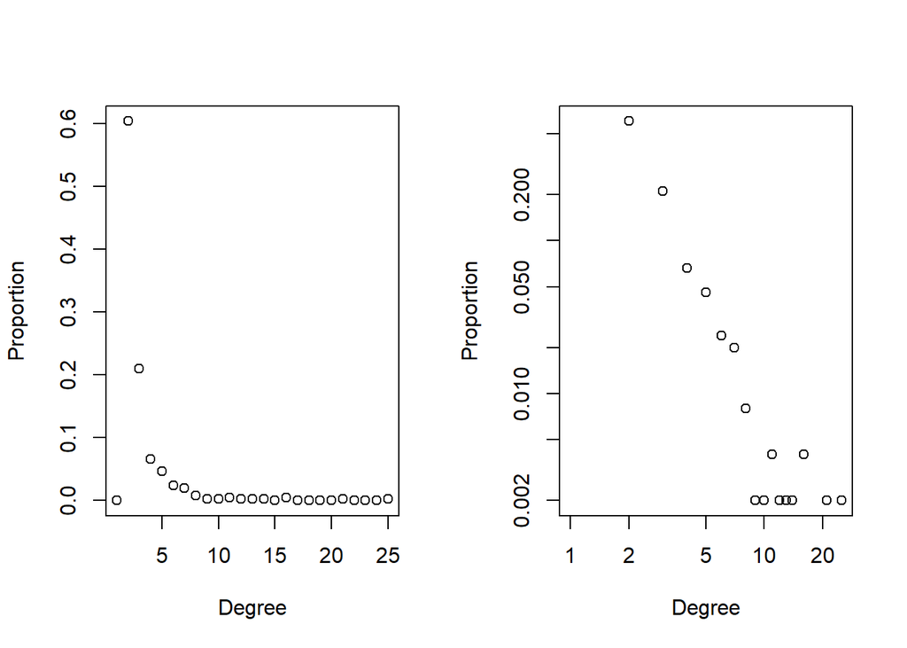

```r
op <- par(mfrow=c(1,2))
plot(degree.distribution(g),xlab="Degree",
     ylab="Proportion")
plot(degree.distribution(g),log='xy',
     xlab="Degree",ylab="Proportion")
```

```r
par(op)
```

By varying some of the parameters of the model, we can get somewhat more realistic networks.

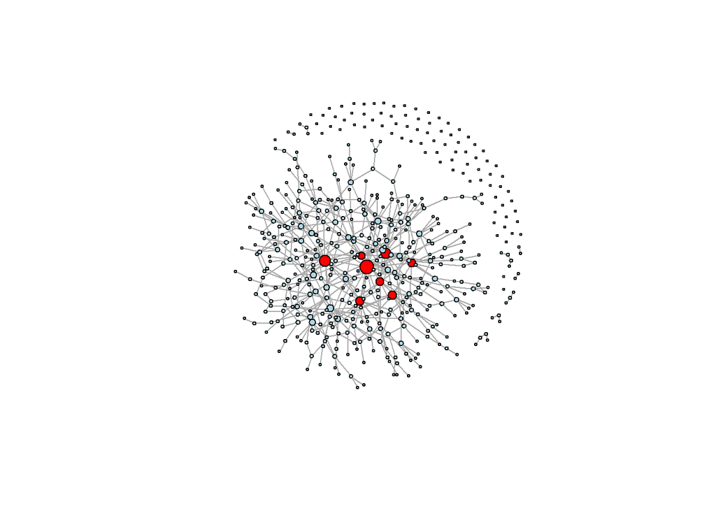

```r
g <- sample_pa(500,out.dist=c(.25,.5,.25),
                   directed=FALSE,zero.appeal = 1)
V(g)$color <- 'lightblue'
V(g)[degree(g) > 9]$color <- 'red'
node_size <- rescale(node_char=degree(g),
                     low=2,high=10)
plot(g, vertex.label= NA, vertex.size = node_size)
```